# New York Student Outcomes and School Closures

This link is to our github.io site: https://ethanperello.github.io/

## **New York Student Outcomes and School Closures**

## **Ethan Perello and Adam Goodman**

[figure not shown]

[figure not shown]

[figure not shown]

## **Introduction**

This collaborative project between Ethan Perello and Adam Goodman will be investigating data collected on high school student outcomes, and school closure statistics to assess the factors that cause schools to close and understand which schools are at risk of closure in New York.

The school closures dataset identifies which schools have closed in 2015 and 2016. The 2015 closures are from https://data.cityofnewyork.us/Education/2014-2015-School-Closure-Discharge-Reporting-GPA/qd93-w582 in a .csv format and the 2016 closures are copied from an online document at https://infohub.nyced.org/docs/default-source/default-document-library/201516schoolclosuredischargereportingnarrative.pdf. We wanted to explore more recent school closure data, but 2015 and 2016 was the most recent that we could find.

The student outcomes dataset contains graduation rates and outcomes for students in different subgroups of race, economic status, sex, disability, and english learning for each school in 2021. This dataset comes from https://data.nysed.gov/downloads.php in a .csv format. Each observation is a subgroup of a graduating class at one high school.

We chose to explore school closure data because many schools are closed in the U.S and school closure can have a negative effect on the students at closed schools. According to the Manhattan Institue for Policy Research: "In many cases, schools are closed in response to declining populations or other factors that led to a substantial decline in available resources. In other cases, school boards and elected officials struggle with the decision of what to do with persistently ineffective schools." <sup>1</sup> Being able to understand what factors cause closures could help prevent school closures. This would help many students and save resources.

We chose to explore student outcome data because student outcomes are an indicator of student success. We suspect that there may be a relationship between students outcomes and school closures and we wanted to see how schools that closed performed relative to other schools. If there actually is a relationship between student outcomes and school closures, we could use a supervised machine learning model to predict schools that are at risk of closing. It is important to acknowledge that many schools closed are charter schools that closed due to financial reasons, but we still believe a relationship may exist between student outcomes and closures.

<sup>1</sup> https://files.eric.ed.gov/fulltext/ED599013.pdf

**Questions:**

How do different subgroups of students perform relative to each other?

How related are student outcomes and whether or not a school is closed?

Can student outcome data for subgroups of students be used to identify which schools are at risk of closing?

## **ETL (Extract, Transform, and Load Data)**

```python
#importing necessary libraries
import pandas as pd
import numpy as np
import matplotlib.pyplot as plt

#to display dataframes
pd.set_option('display.max_columns', None)
pd.set_option('display.max_rows', None)

#connecting to Google Drive to load data
from google.colab import drive
drive.mount('/content/drive')
%cd /content/drive/MyDrive/DataScienceProject/data
```

```
/content/drive/MyDrive/DataScienceProject/data
```

### Student Outcomes

First, we load the student outcomes data into a pandas dataframe. Lets take a look at what this dataframe contains.

```python
#importing our first data set
grad_rate_df = pd.read_csv('GRAD_RATE_AND_OUTCOMES_2021.csv', low_memory=False)

#to view columns, data types, and missing data
grad_rate_df.info()
```

```
<class 'pandas.core.frame.DataFrame'>
RangeIndex: 220304 entries, 0 to 220303
Data columns (total 36 columns):
 #   Column                      Non-Null Count   Dtype
---  ------                      --------------   -----
 0   report_school_year          220304 non-null  object
 1   aggregation_index           220304 non-null  int64
 2   aggregation_type            220304 non-null  object
 3   aggregation_code            220304 non-null  int64
 4   aggregation_name            220254 non-null  object
 5   lea_beds                    130282 non-null  float64
 6   lea_name                    130282 non-null  object
 7   nrc_code                    212252 non-null  float64
 8   nrc_desc                    212252 non-null  object
 9   county_code                 219218 non-null  float64
```

[output cut: 28 more lines]

To do calculations with the data, we need to replace dashes with NaNs and convert the columns to datatypes that are useful to us.

```python
#replace dashes with NaNs
grad_rate_df = grad_rate_df.replace('-', np.nan)

#convert columns to appropriate datatypes
grad_rate_df['grad_pct'] = grad_rate_df['grad_pct'].str.rstrip('%').astype('float') / 100.0
grad_rate_df['still_enr_pct'] = grad_rate_df['still_enr_pct'].str.rstrip('%').astype('float') / 100.0
grad_rate_df['ged_pct'] = grad_rate_df['ged_pct'].str.rstrip('%').astype('float') / 100.0
grad_rate_df['dropout_pct'] = grad_rate_df['dropout_pct'].str.rstrip('%').astype('float') / 100.0
```

This dataset contains data for many aggregation groups that provide no value to what we want to learn about school closure, so we focus on individual schools and their 4-year graduation rate for each subgroup. We also drop the columns that do not contain useful information about student outcomes.

```python
#only keep data for schools and 4-year graduation rate
by_school = grad_rate_df.loc[grad_rate_df.aggregation_index==4]
by_school = by_school[by_school.membership_code==9]
by_school = by_school.reset_index(drop=True)
by_school = by_school.groupby(["aggregation_name", "subgroup_name"]).mean()

#simplying dataframe to have only the useful statistics
grad_rate_df = by_school[['aggregation_code',	'nyc_ind',	'grad_pct', 'still_enr_pct',	'ged_pct',	'dropout_pct']]
grad_rate_df = grad_rate_df.reset_index()
grad_rate_df['aggregation_code']=grad_rate_df['aggregation_code'].astype('int').astype('string')
```

The dataframe is now cleaned up and organized in a way that is useful to us.

```python
grad_rate_df.head()
```

|  | aggregation_name | subgroup_name | aggregation_code | nyc_ind | grad_pct | still_enr_pct | ged_pct | dropout_pct |
| --- | --- | --- | --- | --- | --- | --- | --- | --- |
| 0 | A PHILIP RANDOLPH CAMPUS HIGH SCHOOL | All Students | 310600011540 | 1.0 | 0.79 | 0.15 | 0.01 | 0.05 |
| 1 | A PHILIP RANDOLPH CAMPUS HIGH SCHOOL | American Indian or Alaska Native | 310600011540 | 1.0 | NaN | NaN | NaN | NaN |
| 2 | A PHILIP RANDOLPH CAMPUS HIGH SCHOOL | Asian or Native Hawaiian/Other Pacific Islander | 310600011540 | 1.0 | 1.00 | 0.00 | 0.00 | 0.00 |
| 3 | A PHILIP RANDOLPH CAMPUS HIGH SCHOOL | Black or African American | 310600011540 | 1.0 | 0.80 | 0.13 | 0.02 | 0.03 |
| 4 | A PHILIP RANDOLPH CAMPUS HIGH SCHOOL | Economically Disadvantaged | 310600011540 | 1.0 | 0.78 | 0.15 | 0.01 | 0.05 |

`aggregation_name`: name of the school

`subgroup_name`: name of the subgroup

`aggregation_code`: code for the school

`nyc_inc`: 1 if school is in NYC and 0 otherwise

`grad_pct`: graduation rate for subgroup at school

`still_enr_pct`: percent still enrolled for subgroup at school

`ged_pct`: percent that recieved GED for subgroup at school

`dropout_pct`: percent that dropped out for supgroup at school

### School Closures

Next we make a dataframe with the schools that closed in 2015 and 2016. We create a new variable called `closed` and set it equal to 1 for all these schools.

```python
#load 2015 data
closure_df = pd.read_csv('2014-2015_School_Closure_Discharge_Reporting_-_GPA.csv')
names2015 = closure_df['SchoolName'].unique()
names2015 = names2015[:5], names2015[6:10]
names2015 = np.concatenate(names2015)
names2015 = [x.upper() for x in names2015]

#2016 data
names2016 = ['BREAD AND ROSES INTEGRATED ARTS HIGH SCHOOL', 'BUSINESS COMPUTER APPLICATIONS AND ENTREPRENEURSHIP HS', 'CHOIR ACADEMY OF HARLEM', 'HIGH SCHOOL OF GRAPHIC COMMUNICIATION ARTS', 'JONATHAN LEVIN HIGH SCHOOL FOR MEDIA AND COMMUNICATIONS', 'LAW GOVERNMENT AND COMMUNITY SERVICE HIGH SCHOOL', 'SHEAPSHEAD BAY HIGH SCHOOL', 'FOUNDATIONS ACADEMY', 'FOREIGN LANGUAGE ACADEMY OF GLOBAL STUDIES']
names = names2015 + names2016

#create "closed" variable
closed_df = pd.DataFrame()
closed_df['aggregation_name'] = names
closed_df['closed'] = 1
closed_df['closed'] = closed_df['closed'].fillna(0)
closed_df
```

|  | aggregation_name | closed |
| --- | --- | --- |
| 0 | LEGACY SCHOOL FOR INTEGRATED STUDIES | 1 |
| 1 | WASHINGTON IRVING HIGH SCHOOL | 1 |
| 2 | MANHATTAN THEATRE LAB HIGH SCHOOL | 1 |
| 3 | M.S. 203 | 1 |
| 4 | SAMUEL GOMPERS CAREER AND TECHNICAL EDUCATION ... | 1 |
| 5 | GATEWAY SCHOOL FOR ENVIRONMENTAL RESEARCH AND ... | 1 |
| 6 | JANE ADDAMS HIGH SCHOOL FOR ACADEMIC CAREERS | 1 |
| 7 | GRACE DODGE CAREER AND TECHNICAL EDUCATION HIG... | 1 |
| 8 | INTERNATIONAL ARTS BUSINESS SCHOOL | 1 |
| 9 | BREAD AND ROSES INTEGRATED ARTS HIGH SCHOOL | 1 |
| 10 | BUSINESS COMPUTER APPLICATIONS AND ENTREPRENEU... | 1 |
| 11 | CHOIR ACADEMY OF HARLEM | 1 |
| 12 | HIGH SCHOOL OF GRAPHIC COMMUNICIATION ARTS | 1 |
| 13 | JONATHAN LEVIN HIGH SCHOOL FOR MEDIA AND COMMU... | 1 |
| 14 | LAW GOVERNMENT AND COMMUNITY SERVICE HIGH SCHOOL | 1 |
| 15 | SHEAPSHEAD BAY HIGH SCHOOL | 1 |
| 16 | FOUNDATIONS ACADEMY | 1 |
| 17 | FOREIGN LANGUAGE ACADEMY OF GLOBAL STUDIES | 1 |

We then load student outcome data for 2015 so we can see how closed schools compare. We chose to use 2015 school data because it contains data for the 2015 closed schools and 2016 closed schools.

```python
grad_2015_df = pd.read_csv('GRAD_RATE_AND_OUTCOMES_2015.csv', low_memory=False)
```

To compare years we have to make the column names and types match up with the 2021 dataframe.

```python
#replace dashes with NaNs
grad_2015_df = grad_2015_df.replace('-', np.nan)

#make columns lowercase to match other dataframe
grad_2015_df.columns = grad_2015_df.columns.str.lower()

#make types match
grad_2015_df['grad_pct'] = grad_2015_df['grad_pct'].str.rstrip('%').astype('float') / 100.0
grad_2015_df['still_enr_pct'] = grad_2015_df['still_enr_pct'].str.rstrip('%').astype('float') / 100.0
grad_2015_df['ged_pct'] = grad_2015_df['ged_pct'].str.rstrip('%').astype('float') / 100.0
grad_2015_df['dropout_pct'] = grad_2015_df['dropout_pct'].str.rstrip('%').astype('float') / 100.0

#drop columns and rows that are not useful
by_school = grad_2015_df.loc[grad_2015_df.aggregation_index==4]
by_school = by_school[by_school.membership_code==9]
by_school = by_school.reset_index(drop=True)
by_school = by_school.groupby(["aggregation_name", "subgroup_name"]).mean()
grad_2015_df = by_school[['aggregation_code',	'nyc_ind',	'grad_pct', 'still_enr_pct',	'ged_pct',	'dropout_pct']]
grad_2015_df = grad_2015_df.reset_index()
grad_2015_df['aggregation_code']=grad_rate_df['aggregation_code'].astype('int').astype('string')
grad_2015_df = grad_2015_df.fillna(0)
```

Now we can merge the closed schools dataframe with the student outcome data. We replace all NaNs with 0s because for our data they represent that a school had 0 students for a particular subgroup.

```python
df_2015=closed_df.merge(grad_2015_df, how='right')
df_2015=df_2015.fillna(0)
```

The subgroup names do not match up between years so we have to make those match up.

```python
#fix names to match 2021 dataframe
df_2015['subgroup_name'] = df_2015.subgroup_name.replace('Asian or Pacific Islander', 'Asian or Native Hawaiian/Other Pacific Islander')
df_2015 = df_2015.loc[df_2015.subgroup_name!='Formerly Limited English Proficient']
df_2015['subgroup_name'] = df_2015.subgroup_name.replace('Limited English Proficient', 'English Language Learner')
df_2015['subgroup_name'] = df_2015.subgroup_name.replace('Not Limited English Proficient', 'Non-English Language Learner')

#drop names of subgroups not in 2021 dataframe
df_2021 = grad_rate_df
df_2021 = df_2021.loc[df_2021.subgroup_name!='Homeless']
df_2021 = df_2021.loc[df_2021.subgroup_name!='In Foster Care']
df_2021 = df_2021.loc[df_2021.subgroup_name!='Not in Foster Care']
df_2021 = df_2021.loc[df_2021.subgroup_name!='Parent Not in Armed Forces']
df_2021 = df_2021.loc[df_2021.subgroup_name!='Parent in Armed Forces']
df_2021 = df_2021.loc[df_2021.subgroup_name!='Not Homeless']
```

We now have a dataframe containing student outcome data from 2015 and school closure data from 2015 and 2016.

```python
df_2015.head()
```

|  | aggregation_name | closed | subgroup_name | aggregation_code | nyc_ind | grad_pct | still_enr_pct | ged_pct | dropout_pct |
| --- | --- | --- | --- | --- | --- | --- | --- | --- | --- |
| 0 | A PHILIP RANDOLPH CAMPUS HIGH SCHOOL | 0.0 | All Students | 310600011540 | 1.0 | 0.75 | 0.18 | 0.0 | 0.02 |
| 1 | A PHILIP RANDOLPH CAMPUS HIGH SCHOOL | 0.0 | American Indian or Alaska Native | 310600011540 | 1.0 | 0.00 | 0.00 | 0.0 | 0.00 |
| 2 | A PHILIP RANDOLPH CAMPUS HIGH SCHOOL | 0.0 | Asian or Native Hawaiian/Other Pacific Islander | 310600011540 | 1.0 | 0.00 | 0.00 | 0.0 | 0.00 |
| 3 | A PHILIP RANDOLPH CAMPUS HIGH SCHOOL | 0.0 | Black or African American | 310600011540 | 1.0 | 0.77 | 0.14 | 0.0 | 0.04 |
| 4 | A PHILIP RANDOLPH CAMPUS HIGH SCHOOL | 0.0 | Economically Disadvantaged | 310600011540 | 1.0 | 0.78 | 0.16 | 0.0 | 0.01 |

## **EDA (Exploratory Data Ananlysis)**

### Student Outcomes

The first thing we wanted to explore was how graduation rates differ by individual subgroup. To do this we can look at a bar graph of the mean graduation rate by subgroup for 2021.

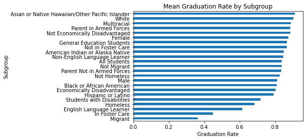

```python
df = grad_rate_df[["subgroup_name", "grad_pct"]]
means = df.groupby(df.subgroup_name).mean().sort_values(by="grad_pct")
means.plot.barh(legend=None)
plt.ylabel("Subgroup")
plt.xlabel("Graduation Rate")
plt.title("Mean Graduation Rate by Subgroup")
plt.show()
```

Graduation rates differ greatly between race, gender, and economic status.

To explore this further we can look at histograms of graduation rates by subgroup.

```python
#function to help us plot subgroups
def plot_subgroups(subgroups, title):
  df = grad_rate_df[["aggregation_name", 'subgroup_name', "grad_pct"]]
  for subgroup in subgroups:
    indices=[]
    for i in range(0,len(df)):
      if df.iloc[i].subgroup_name == subgroup:
        indices.append(i)
    grad_pcts = df.iloc[indices]['grad_pct']
    plt.hist(grad_pcts, bins=20, alpha=0.2, label=subgroup)
  plt.legend(loc='upper right')
  plt.ylabel("Frequency")
  plt.xlabel("Graduation Rate")
  plt.title(title)
  plt.show()
```

The graduation rate for females is significantly higher than for males so lets look at a histogram of males vs females.

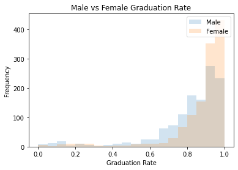

```python
subgroups = ['Male','Female']
title = "Male vs Female Graduation Rate"
plot_subgroups(subgroups, title)
```

It is significantly more common to have a female graduation rate above 95 percent than to have a male graduation above 95 percent. It is significantly more common to have a male graduation rate below 85 percent than to have a female graduation rate below 85 percent.

The graduation rate for white students is significantly higher than black and hispanic students so lets look at a histogram comparing these subgroups.

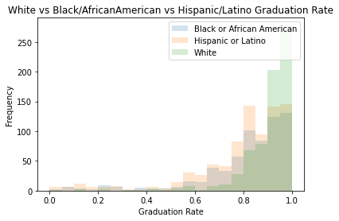

```python
subgroups = ['Black or African American','Hispanic or Latino', 'White']
title = "White vs Black/AfricanAmerican vs Hispanic/Latino Graduation Rate"
plot_subgroups(subgroups, title)
```

It is significantly more common to have a white graduation rate above 90 percent than to have a black or hispanic graduation above 90 percent. It is significantly more common to have a black or hispanic graduation rate below 85 percent than to have a white graduation rate below 85 percent.

### School Closures

The next thing we want to explore is how related student outcomes for each subgroup are to school closure. Because we have data for 17 subgroups at every school, we can turn the 4 variables for each subgroup into their own variables. We can then see how each variable relates to school closure.

```python
#create new variables for outcomes of each subgroup
df = df_2015
new_df = df_2015
subgroups=df['subgroup_name'].unique()
columns=['grad_pct', 'still_enr_pct', 'ged_pct', 'dropout_pct']
for subgroup in subgroups:
  for col in columns:
    new_col = subgroup + " " + col
    new_df[new_col] = df.loc[df.subgroup_name==subgroup][col]
new_df = df.groupby(['aggregation_name', 'aggregation_code']).max()
new_df = new_df.drop(["subgroup_name", 'grad_pct', 'still_enr_pct', 'ged_pct', 'dropout_pct'], axis=1)
new_df = new_df.reset_index()
```

Let's take a look at all the variables we now have for each school.

```python
variables=new_df.columns.drop(["aggregation_name", 'aggregation_code', 'closed']).astype(str)
for i in variables:
  print(i)
```

```
nyc_ind
All Students grad_pct
All Students still_enr_pct
All Students ged_pct
All Students dropout_pct
American Indian or Alaska Native grad_pct
American Indian or Alaska Native still_enr_pct
American Indian or Alaska Native ged_pct
American Indian or Alaska Native dropout_pct
Asian or Native Hawaiian/Other Pacific Islander grad_pct
Asian or Native Hawaiian/Other Pacific Islander still_enr_pct
Asian or Native Hawaiian/Other Pacific Islander ged_pct
Asian or Native Hawaiian/Other Pacific Islander dropout_pct
Black or African American grad_pct
Black or African American still_enr_pct
Black or African American ged_pct
Black or African American dropout_pct
Economically Disadvantaged grad_pct
Economically Disadvantaged still_enr_pct
Economically Disadvantaged ged_pct
Economically Disadvantaged dropout_pct
Female grad_pct
Female still_enr_pct
Female ged_pct
Female dropout_pct
General Education Students grad_pct
General Education Students still_enr_pct
General Education Students ged_pct
General Education Students dropout_pct
Hispanic or Latino grad_pct
Hispanic or Latino still_enr_pct
Hispanic or Latino ged_pct
Hispanic or Latino dropout_pct
English Language Learner grad_pct
English Language Learner still_enr_pct
English Language Learner ged_pct
English Language Learner dropout_pct
Male grad_pct
Male still_enr_pct
Male ged_pct
```

[output cut: 14 more lines]

```
Students with Disabilities still_enr_pct
Students with Disabilities ged_pct
Students with Disabilities dropout_pct
White grad_pct
White still_enr_pct
White ged_pct
White dropout_pct
Multiracial grad_pct
Multiracial still_enr_pct
Multiracial ged_pct
Multiracial dropout_pct
Migrant grad_pct
Migrant still_enr_pct
Migrant ged_pct
Migrant dropout_pct
```

We now have a lot of variables, but we want to see which of these variables are most correlated with school closure. To do this we can plot a bar graph of the 20 most correlated variables to the school closure variable.

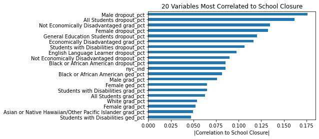

```python
correlations = new_df.corr()
correlations = abs(correlations["closed"])
correlations = correlations.sort_values().drop("closed").dropna().tail(20)
correlations.plot.barh()
plt.xlabel('|Correlation to School Closure|')
plt.title("20 Variables Most Correlated to School Closure")
plt.show()
```

None of the variables have a correlation above 0.2 which implies that each individual variable by itself is not very closely related to school closure. Dropout percents for different subgroups seems to be the most correlated to closure. Variables for the 'Black or African American' subgroup seem to have a higher correlation than variables for other racial subgroups.

## **Model to Predict School Closure**

### Train Model

To predict schools at risk of closure, we decided to use a classification model. We will be using logistic regression which is a linear classification model. The model will learn on student outcomes and school closure data from 2015 to predict school closures. We will then apply this model to our 2021 data to find schools at risk of closing today. We are trying to solve the problem of having missing school closure data in 2021 by using student outcome data from 2021 and 2015 of the same metrics.

```python
#import necessary packages
from sklearn.preprocessing import StandardScaler
from sklearn.linear_model import LogisticRegression
from sklearn.model_selection import cross_val_score
```

We set the student outcome variables as the features and the closed variable as the target for the model.

```python
train_df = new_df.fillna(0)
train_df=train_df.reset_index()
X_train = train_df[(train_df.drop(["aggregation_name", "aggregation_code", "closed"], axis=1)).columns]
y_train = train_df["closed"].astype(int)
```

We use StandardScaler() from sklearn to scale the data because not all of our variables are on the same scale.

```python
scaler = StandardScaler()
scaler.fit(X_train)
X_train_sc = scaler.transform(X_train)
```

We then use LogisticRegression() from sklearn and train the model to predict closures from 2015 using student outcome data.

```python
model = LogisticRegression()
model.fit(X_train_sc, y_train.ravel())
```

```
LogisticRegression()
```

To see how effective our model is at predicting schools to close that actually closed, we perform 5-fold cross-validation on the 2015 data.

```python
scores = cross_val_score(model, X_train_sc, y_train, cv=5)
print("Average Accuracy:", scores.mean())
```

```
Average Accuracy: 0.9908779812983013
```

The model has an average cross-validation accuracy of approximately 0.9909 which is very high. This means that our model is very effective at predicting the actual result of whether or not schools in 2015 closed.

### Apply Model

Now that we have trained the model, we can apply it. We will be applying it to the 2021 student outcomes data to predict which of those schools will close.

```python
#create new columns for each subgroup in the 2021 dataframe so that they can be used as features
df = df_2021
subgroups=df['subgroup_name'].unique()
columns=['grad_pct', 'still_enr_pct', 'ged_pct', 'dropout_pct']
for subgroup in subgroups:
  for col in columns:
    new_col = subgroup + " " + col
    df[new_col] = df.loc[df.subgroup_name==subgroup][col]
df = df.groupby(['aggregation_name', 'aggregation_code']).max().drop(["subgroup_name", 'grad_pct', 'still_enr_pct', 'ged_pct', 'dropout_pct'], axis=1)
test_df = df.fillna(0)
test_df = test_df.reset_index()
```

```python
#scale the test data and predict
X = test_df[(test_df.drop(["aggregation_name", "aggregation_code"], axis=1)).columns].reset_index()
scaler.fit(X)
X_sc = scaler.transform(X)
y_pred = model.predict(X_sc)
test_df['pred_close'] = y_pred
at_risk = test_df.loc[test_df.pred_close==1]
at_risk = list(at_risk['aggregation_code'])
```

We can now find the names of the schools that our model predicted to close. Lets look at the prediction probabilities for each school to see how confident our model is in these predictions.

```python
probs = model.predict_proba(X_sc)
test_df[['pred_prob', 'prob_incorrect']] = probs
test_df[["aggregation_name", "pred_close", "pred_prob"]].loc[test_df.pred_close==1]
```

|  | aggregation_name | pred_close | pred_prob |
| --- | --- | --- | --- |
| 19 | ACADEMY SCHOOL | 1 | 0.380327 |
| 158 | BROOKLYN BRIDGE ACADEMY | 1 | 0.402102 |
| 377 | ENGLISH LANGUAGE LEARNERS AND INTERNATIO | 1 | 0.020541 |
| 633 | JHS 74 NATHANIEL HAWTHORNE | 1 | 0.339249 |
| 731 | MANHATTAN ACADEMY FOR ARTS AND LANGUAGES | 1 | 0.195684 |
| 750 | MARTIN LUTHER KING JR HIGH SCHOOL | 1 | 0.417368 |
| 769 | METROPOLITAN HIGH SCHOOL (THE) | 1 | 0.050744 |
| 833 | NEW VISIONS CHARTER HIGH SCHOOL FOR ADVA | 1 | 0.311228 |
| 835 | NEW VISIONS CHARTER HIGH SCHOOL FOR ADVA | 1 | 0.310954 |
| 836 | NEW VISIONS CHARTER HIGH SCHOOL FOR THE | 1 | 0.043865 |
| 837 | NEW VISIONS CHARTER HIGH SCHOOL FOR THE | 1 | 0.310680 |
| 839 | NEW VISIONS CHARTER HIGH SCHOOL FOR THE | 1 | 0.310407 |
| 840 | NEW VISIONS CHARTER HIGH SCHOOL FOR THE | 1 | 0.316849 |
| 877 | NYC AUTISM CHARTER SCHOOL EAST HARLEM | 1 | 0.067144 |
| 911 | PAN AMERICAN INTERNATIONAL HIGH SCHOOL A | 1 | 0.162371 |
| 960 | PS 116 MARY LINDLEY MURRAY | 1 | 0.294110 |
| 961 | PS 24 SPUYTEN DUYVIL | 1 | 0.293978 |
| 963 | PS 43 | 1 | 0.293713 |
| 1172 | URBAN ASSEMBLY CHARTER SCHOOL FOR COMPUT | 1 | 0.266801 |
| 1276 | WINDHAM ASHLAND CENTRAL SCHOOL | 1 | 0.393549 |

Our model seems to be somewhat confident with its predictions, with most of the prediction probabilites being around 0.3. The model is also not confident at all with a few of its predictions which is interesting. This may be due to some schools lacking subgroups to be used as features.

## **Analysis of Schools Predicted to Close**

This dataframe shows student outcomes for each subgroup at the schools our model predicted to close.

```python
#filter for student outcomes at schools predicted to close
pred_closes = pd.DataFrame()
for school in at_risk:
  pred_close = grad_rate_df.loc[grad_rate_df.aggregation_code==school]
  pred_closes = pd.concat((pred_closes, pred_close)).reset_index(drop=True)
pred_closes = pred_closes.fillna(0)

pred_closes.head()
```

|  | aggregation_name | subgroup_name | aggregation_code | nyc_ind | grad_pct | still_enr_pct | ged_pct | dropout_pct |
| --- | --- | --- | --- | --- | --- | --- | --- | --- |
| 0 | ACADEMY SCHOOL | All Students | 140600010133 | 0.0 | 0.13 | 0.36 | 0.0 | 0.51 |
| 1 | ACADEMY SCHOOL | American Indian or Alaska Native | 140600010133 | 0.0 | 0.00 | 0.00 | 0.0 | 0.00 |
| 2 | ACADEMY SCHOOL | Black or African American | 140600010133 | 0.0 | 0.12 | 0.37 | 0.0 | 0.51 |
| 3 | ACADEMY SCHOOL | Economically Disadvantaged | 140600010133 | 0.0 | 0.17 | 0.33 | 0.0 | 0.50 |
| 4 | ACADEMY SCHOOL | English Language Learner | 140600010133 | 0.0 | 0.00 | 0.33 | 0.0 | 0.67 |

Lets make some plots of dropout rate vs graduation rate for relevant subgroups to see how these schools compare to other schools in 2021 and to the schools that closed in 2015.

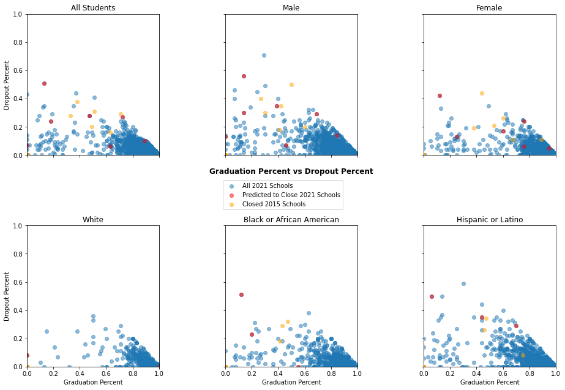

```python
fig, ((ax1, ax2, ax3), (ax4, ax5, ax6)) = plt.subplots(2, 3)

#plot for all students
ax1.scatter(test_df[["All Students grad_pct"]], test_df[["All Students dropout_pct"]], label="All 2021 Schools", alpha=.5)
ax1.scatter(test_df.loc[test_df.pred_close==1][["All Students grad_pct"]], test_df.loc[test_df.pred_close==1][["All Students dropout_pct"]], color="red", label="Predicted to Close 2021 Schools", alpha=.5)
ax1.scatter(train_df.loc[train_df.closed==1][["All Students grad_pct"]], train_df.loc[train_df.closed==1][["All Students dropout_pct"]], color="orange", label="Closed 2015 Schools", alpha=.5)
ax1.set_title("All Students")
ax1.set_ylim(0,1)
ax1.set_xlim(0,1)

#plot for male
ax2.scatter(test_df[["Male grad_pct"]], test_df[["Male dropout_pct"]], alpha=.5)
ax2.scatter(test_df.loc[test_df.pred_close==1][["Male grad_pct"]], test_df.loc[test_df.pred_close==1][["Male dropout_pct"]], color="red", alpha=.5)
ax2.scatter(train_df.loc[train_df.closed==1][["Male grad_pct"]], train_df.loc[train_df.closed==1][["Male dropout_pct"]], color="orange", alpha=.5)
ax2.set_title("Male")
ax2.set_ylim(0,1)
ax2.set_xlim(0,1)

#plot for female
ax3.scatter(test_df[["Female grad_pct"]], test_df[["Female dropout_pct"]], alpha=.5)
ax3.scatter(test_df.loc[test_df.pred_close==1][["Female grad_pct"]], test_df.loc[test_df.pred_close==1][["Female dropout_pct"]], color="red", alpha=.5)
ax3.scatter(train_df.loc[train_df.closed==1][["Female grad_pct"]], train_df.loc[train_df.closed==1][["Female dropout_pct"]], color="orange", alpha=.5)
ax3.set_title("Female")
ax3.set_ylim(0,1)
ax3.set_xlim(0,1)

#plot for white
ax4.scatter(test_df[["White grad_pct"]], test_df[["White dropout_pct"]], alpha=.5)
ax4.scatter(test_df.loc[test_df.pred_close==1][["White grad_pct"]], test_df.loc[test_df.pred_close==1][["White dropout_pct"]], color="red", alpha=.5)
ax4.scatter(train_df.loc[train_df.closed==1][["White grad_pct"]], train_df.loc[train_df.closed==1][["White dropout_pct"]], color="orange", alpha=.5)
ax4.set_title("White")
ax4.set_ylim(0,1)
ax4.set_xlim(0,1)

#plot for black or african american
ax5.scatter(test_df[["Black or African American grad_pct"]], test_df[["Black or African American dropout_pct"]], alpha=.5)
ax5.scatter(test_df.loc[test_df.pred_close==1][["Black or African American grad_pct"]], test_df.loc[test_df.pred_close==1][["Black or African American dropout_pct"]], color="red", alpha=.5)
ax5.scatter(train_df.loc[train_df.closed==1][["Black or African American grad_pct"]], train_df.loc[train_df.closed==1][["Black or African American dropout_pct"]], color="orange", alpha=.5)
ax5.set_title("Black or African American")
ax5.set_ylim(0,1)
ax5.set_xlim(0,1)

#plot for hispanic or latino
ax6.scatter(test_df[["Hispanic or Latino grad_pct"]], test_df[["Hispanic or Latino dropout_pct"]], alpha=.5)
ax6.scatter(test_df.loc[test_df.pred_close==1][["Hispanic or Latino grad_pct"]], test_df.loc[test_df.pred_close==1][["Hispanic or Latino dropout_pct"]], color="red", alpha=.5)
ax6.scatter(train_df.loc[train_df.closed==1][["Hispanic or Latino grad_pct"]], train_df.loc[train_df.closed==1][["Hispanic or Latino dropout_pct"]], color="orange", alpha=.5)
ax6.set_title("Hispanic or Latino")
ax6.set_ylim(0,1)
ax6.set_xlim(0,1)

#to make it look pretty
for ax in fig.get_axes():
    ax.set(xlabel='Graduation Percent', ylabel='Dropout Percent')
for ax in fig.get_axes():
    ax.label_outer()
handles, labels = ax1.get_legend_handles_labels()
fig.legend(handles, labels, loc="center")
fig.suptitle("Graduation Percent vs Dropout Percent", x=0, y=0.13, weight='bold')
fig.subplots_adjust(left=-1, right=1, bottom=-1, top=1, wspace=.5, hspace=.5)
fig.show()
```

The closed 2015 schools and predicted to close 2021 schools all seem to be very similar to each other in terms of graduation rates and dropout rates for these subgroups. It is interesting that there are also some schools with similar graduation and dropout rates to the closed schools that were not predicted to close. This indicates there may be a relationship between student outcomes and school closure, but student outcomes are probably not the main determining factor for if a school is closed.

## **Conclusions**

**How do different subgroups of students perform relative to each other?**

Student outcomes in New York differ greatly between subgroups. Female students are significantly more likely to graduate than male students. White students are significantly more likely to graduate than black or hispanic students.

**How related are student outcomes and school closure?**

Some student outcome variables are somewhat correlated with school closure, but none have a very high correlation and some have a very low correlation. Correlations vary quite a bit between subgroups. Variables for the 'Black or African American' subgroup seem to have a higher correlation than variables for other racial subgroups.

**Can student outcome data for subgroups of students be used to identify which schools are at risk of closing?**

Our model using student outcome data for subgroups of students was very effective at predicting the 2015 schools that closed when performing cross-validation. Our model was somewhat confident when predicting which 2021 schools were at risk of closing, but not confident enough where the predictions should be trusted. While the predictions cannot fully be trusted, they do provide insight because the schools predicted to close were very similar to the schools closed in 2015.